# Measuring Feeding Coordination of Dairy Cows Using a Complex Systems Approach

In complex systems science, coordination is the emergence of order from the interaction of independent components. It governs phenomenons such as the synchronous flashing of fireflies, or the phase-locking of metronomes on a shared surface. Unlike centralized systems, where one controller dictates the movement of every part, coordinated systems rely on self-organization. The beauty of coordination lies in its ability to produce sophisticated, functional patterns that are often referred to as emergent properties. They are not present in the individual units themselves. In this paper, we aim to explore emerging coordination in the behavior of dairy cows.

When a cow feeds, it engages in a rhythmic motor pattern. The characteristic head-bobbing of an animal feeding at a trough becomes visible. If cows influence each other through social facilitation, acoustic cues, or simply by sharing the same feeding resource, we might expect their individual rhythms to align. This notebook tests that idea using wearable sensor data.

By treating each cow as an oscillator in the Kuramoto framework, we can move beyond simple correlation and quantify actual coupling strength. We can then ask whether coupling changes depending on what the animals are doing. The plan proceeds through four stages. We begin with raw data exploration to see what the signals actually look like. Next comes phase extraction, which involves turning acceleration into a geometric object using the Hilbert Transform. The third step measures continuous relative phase to quantify moment-to-moment coordination between two cows. Finally, we conduct multiscale windowed analysis to determine whether coordination changes depending on behavioral state.

We focus on two cows. Cow 1 and Cow 2 provide data from July 25th, the only day with behavior annotations. The code below loads and aligns all three streams.

```python
import os
import glob
import pandas as pd
import numpy as np
import matplotlib.pyplot as plt
from scipy.signal import hilbert, butter, filtfilt
from scipy.stats import circmean
from datetime import datetime
import matplotlib.animation as animation
from IPython.display import Video, display

# Behavior code mapping (MmCows dataset)
BEHAVIOR_MAP = {1: 'Walking', 2: 'Standing', 3: 'Feeding head up', 4: 'Feeding head down', 5: 'Licking', 6: 'Drinking', 7: 'Lying', 0: 'Unknown'}

# --- Data Loaders ---
def load_sensor_data(folder_path):
    files = glob.glob(os.path.join(folder_path, "*_0725.csv"))
    if not files: return pd.DataFrame()
    df = pd.concat([pd.read_csv(f) for f in files], ignore_index=True)
    df['timestamp'] = df['timestamp'].astype('float64')
    return df.sort_values('timestamp').drop_duplicates('timestamp')

def load_labels(file_path):
    if not os.path.exists(file_path): return pd.DataFrame()
    df = pd.read_csv(file_path)
    df['timestamp'] = df['timestamp'].astype('float64')
    df['behavior'] = df['behavior'].map(BEHAVIOR_MAP).fillna('Other')
    return df.sort_values('timestamp').drop_duplicates('timestamp')

# --- Load all three data sources (July 25 only) ---
df_c1_imu = load_sensor_data('../data/sensor_data/main_data/immu/T01')
df_c2_imu = load_sensor_data('../data/sensor_data/main_data/immu/T02')
df_c1_uwb = load_sensor_data('../data/sensor_data/main_data/uwb/T01')
df_c2_uwb = load_sensor_data('../data/sensor_data/main_data/uwb/T02')
df_c1_labels = load_labels('../data/sensor_data/behavior_labels/individual/C01_0725.csv')
df_c2_labels = load_labels('../data/sensor_data/behavior_labels/individual/C02_0725.csv')

# --- Align IMU streams (10Hz, nearest-match within 50ms) ---
df_imu = pd.merge_asof(
    df_c1_imu[['timestamp', 'accel_x_mps2']],
    df_c2_imu[['timestamp', 'accel_x_mps2']],
    on='timestamp', suffixes=('_c1', '_c2'), direction='nearest', tolerance=0.05).dropna()

# --- Merge behavior labels for both cows (1Hz -> 10Hz, backward fill within 1s) ---
df_merged = pd.merge_asof(
    df_imu, df_c1_labels[['timestamp', 'behavior']].rename(columns={'behavior': 'behavior_c1'}),
    on='timestamp', direction='backward', tolerance=1.0)
df_merged = pd.merge_asof(
    df_merged, df_c2_labels[['timestamp', 'behavior']].rename(columns={'behavior': 'behavior_c2'}),
    on='timestamp', direction='backward', tolerance=1.0)


print(f"IMU samples (aligned): {len(df_merged):,}")
print(f"UWB samples: Cow 1 = {len(df_c1_uwb):,}, Cow 2 = {len(df_c2_uwb):,}")
print(f"Behavior labels: C1 = {len(df_c1_labels):,}, C2 = {len(df_c2_labels):,}")
print(f"Cow 1 behaviors: {df_merged['behavior_c1'].dropna().unique()}")
print(f"Cow 2 behaviors: {df_merged['behavior_c2'].dropna().unique()}")
```

```
IMU samples (aligned): 832,486
UWB samples: Cow 1 = 5,745, Cow 2 = 5,736
Behavior labels: C1 = 86,400, C2 = 86,400
Cow 1 behaviors: ['Unknown' 'Feeding head down' 'Feeding head up' 'Walking' 'Standing'
 'Drinking' 'Lying']
Cow 2 behaviors: ['Unknown' 'Lying' 'Standing' 'Walking' 'Drinking' 'Feeding head down'
 'Feeding head up' 'Licking']
```

```python
# Constants

# Sampling rate and time parameters
SAMPLING_RATE = 10  # Hz
SECOND_TO_SAMPLES = SAMPLING_RATE

# Observation window for raw data visualization
# OBSERVATION_START is computed dynamically — see proximity analysis cell below
OBSERVATION_LENGTH = 2 * 60 * SECOND_TO_SAMPLES  # 2 minutes in samples

# Signal processing parameters
BANDPASS_LOWFREQ = 0.5  # Hz
BANDPASS_HIGHFREQ = 2.5  # Hz

# Sliding window analysis parameters
WINDOW_SIZE_MINUTES = 5
WINDOW_SIZE_SAMPLES = WINDOW_SIZE_MINUTES * 60 * SAMPLING_RATE  # 3000 samples
WINDOW_OVERLAP_PERCENT = 50
WINDOW_STEP_SIZE = WINDOW_SIZE_SAMPLES // 2  # 50% overlap = 1500 samples

# Behavior color mapping
BEHAVIOR_COLORS = {
    'Feeding': 'green',
    'Resting': 'gray',
    'Walking': 'yellow',
    'Standing': 'yellow',
    'Feeding head up': 'cyan',
    'Feeding head down': 'cyan',
    'Licking': 'pink',
    'Drinking': 'blue',
    'Lying (Rumination proxy)': 'gray',
    'Unknown': 'white'
}

# Helper functions

def center_signal(sig):
    return sig - np.min(sig) - (np.max(sig) - np.min(sig)) / 2

def bandpass_filter(data, fs=SAMPLING_RATE, low_freq=BANDPASS_LOWFREQ, high_freq=BANDPASS_HIGHFREQ):
    b, a = butter(4, [low_freq / (fs / 2), high_freq / (fs / 2)], btype='band')
    return filtfilt(b, a, data)

def extract_phase_angles(signal):
    analytic = hilbert(signal)
    phase_rad = np.arctan2(np.imag(analytic), np.real(analytic))
    phase_deg = np.rad2deg(phase_rad)
    return phase_deg, analytic

def compute_crp(phase1_deg, phase2_deg):
    crp_raw = np.abs(phase1_deg - phase2_deg)
    crp_corrected = np.where(crp_raw > 180, 360 - crp_raw, crp_raw)
    return crp_corrected

def create_kuramoto_animation(sig1, sig2, time_sec, anim_start, anim_duration,
                              mp4_filename='animation.mp4', fps=60):
    anim_samples = anim_duration * SAMPLING_RATE
    anim_end = min(anim_start + anim_samples, len(sig1))

    # Bandpass filter then extract phase via Hilbert transform
    s1_filt = bandpass_filter(sig1)
    s2_filt = bandpass_filter(sig2)
    phase1_rad = np.deg2rad(extract_phase_angles(s1_filt)[0])
    phase2_rad = np.deg2rad(extract_phase_angles(s2_filt)[0])

    # Extract animation segments
    anim_p1 = phase1_rad[anim_start:anim_end]
    anim_p2 = phase2_rad[anim_start:anim_end]
    anim_s1 = s1_filt[anim_start:anim_end]
    anim_s2 = s2_filt[anim_start:anim_end]

    # Upsample to target fps so 1s of data = 1s of video
    total_frames = anim_duration * fps
    t_orig = np.linspace(0, anim_duration, len(anim_p1))
    t_up = np.linspace(0, anim_duration, total_frames)
    p1_up = np.interp(t_up, t_orig, anim_p1)
    p2_up = np.interp(t_up, t_orig, anim_p2)
    s1_up = np.interp(t_up, t_orig, anim_s1)
    s2_up = np.interp(t_up, t_orig, anim_s2)

    fig = plt.figure(figsize=(14, 5))

    # Left: Full filtered signals with animation region highlighted
    ax_context = plt.subplot(1, 3, 1)
    ax_context.plot(time_sec, s1_filt, color='black', alpha=0.5, lw=1.2, label='Cow 1')
    ax_context.plot(time_sec, s2_filt, color='steelblue', alpha=0.5, lw=1.2, label='Cow 2')
    ax_context.axvspan(time_sec[anim_start], time_sec[anim_end - 1],
                       alpha=0.3, color='yellow', label=f'{anim_duration}s window')
    ax_context.set_xlabel('Time in window (s)')
    ax_context.set_ylabel('Acceleration (m/s²)')
    ax_context.set_title('Context: Bandpass-Filtered Signals')
    ax_context.legend(fontsize=8)
    ax_context.grid(True, alpha=0.3)

    # Middle: Zoomed signals with moving dots
    ax_zoom = plt.subplot(1, 3, 2)
    ax_zoom.plot(t_up, s1_up, color='black', alpha=0.6, lw=2, label='Cow 1')
    ax_zoom.plot(t_up, s2_up, color='steelblue', alpha=0.6, lw=2, label='Cow 2')
    dot1, = ax_zoom.plot([], [], 'o', color='black', markersize=9, zorder=5)
    dot2, = ax_zoom.plot([], [], 'o', color='steelblue', markersize=9, zorder=5)
    ax_zoom.set_xlabel('Time (s)')
    ax_zoom.set_ylabel('Acceleration (m/s²)')
    ax_zoom.set_title(f'Zoomed: {anim_duration}s Window')
    ax_zoom.legend(fontsize=8)
    ax_zoom.grid(True, alpha=0.3)

    # Right: Polar circle — both cows on the same unit circle
    ax_polar = plt.subplot(1, 3, 3, projection='polar')
    ax_polar.set_theta_zero_location("N")
    ax_polar.set_theta_direction(-1)
    ax_polar.set_ylim(0, 1.3)
    ax_polar.set_yticks([])
    ax_polar.set_title('Instantaneous Phase (Hilbert)\nRed arc = CRP', pad=20)

    line1, = ax_polar.plot([], [], color='black', lw=2)
    dot_p1, = ax_polar.plot([], [], 'o', color='black', markersize=11, zorder=5, label='Cow 1')
    line2, = ax_polar.plot([], [], color='steelblue', lw=2)
    dot_p2, = ax_polar.plot([], [], 'o', color='steelblue', markersize=11, zorder=5, label='Cow 2')
    arc, = ax_polar.plot([], [], color='red', lw=3, alpha=0.7)
    ax_polar.legend(loc='upper right', bbox_to_anchor=(1.35, 1.1), fontsize=8)

    def animate(i):
        dot1.set_data([t_up[i]], [s1_up[i]])
        dot2.set_data([t_up[i]], [s2_up[i]])

        th1, th2 = p1_up[i], p2_up[i]

        line1.set_data([th1, th1], [0, 1])
        dot_p1.set_data([th1], [1])

        line2.set_data([th2, th2], [0, 1])
        dot_p2.set_data([th2], [1])

        # Arc connecting the two phase dots (drawn slightly outside r=1)
        arc_theta = np.linspace(th1, th2, 50)
        arc.set_data(arc_theta, np.full(50, 1.12))

        return dot1, dot2, line1, dot_p1, line2, dot_p2, arc

    plt.tight_layout()
    print(f"Rendering {total_frames} frames ({anim_duration}s at {fps}fps)...")
    print(f"  Window: {time_sec[anim_start]:.1f}–{time_sec[anim_end - 1]:.1f} seconds")

    anim = animation.FuncAnimation(fig, animate, frames=total_frames, interval=1000/fps, blit=False)
    anim.save(mp4_filename, writer='ffmpeg', fps=fps, dpi=100)
    plt.close(fig)

    print(f"  Saved to {mp4_filename}")
    return mp4_filename
```

## Part 1 Examining the Raw Data

Before computing anything, it is worth looking at the raw signals and plotting them to get an overview of the data at hand. The goal of our analysis is to find a 2 minute slice in the data that is particularly interesting in terms of coordination.

We will then overlay both cows' neck acceleration signals for that window, colored by annotated behavior. We can already make a few assumptions based on the labelled behavior. Feeding should produce high-amplitude, rhythmic oscillations. This reflects the up-down head motion at the trough. Lying should be comparatively flat, with very little head movement. The question becomes whether the two signals appear to be in step at any point, or whether they look largely independent.

```
Best proximity window:
  04:59:11 – 05:29:11
  Mean inter-cow distance: 79 cm (0.8 m)
-> OBSERVATION_START = 762702 (IMU sample index)
```

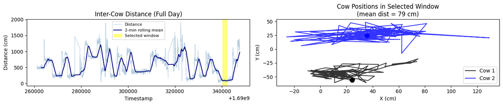

```python
# Align UWB streams (both ~1 Hz, match within 2s)
df_uwb_aligned = pd.merge_asof(
    df_c1_uwb[['timestamp', 'coord_x_cm', 'coord_y_cm']],
    df_c2_uwb[['timestamp', 'coord_x_cm', 'coord_y_cm']],
    on='timestamp', suffixes=('_c1', '_c2'), direction='nearest', tolerance=2.0
).dropna().reset_index(drop=True)

# Euclidean distance between cows at each UWB sample
df_uwb_aligned['distance_cm'] = np.sqrt(
    (df_uwb_aligned['coord_x_cm_c1'] - df_uwb_aligned['coord_x_cm_c2'])**2 +
    (df_uwb_aligned['coord_y_cm_c1'] - df_uwb_aligned['coord_y_cm_c2'])**2
)

# Find the 2-minute window (~120 UWB samples at 1 Hz) with the lowest mean distance
WIN_UWB = 120
rolling_mean_dist = df_uwb_aligned['distance_cm'].rolling(WIN_UWB, min_periods=WIN_UWB).mean()
best_end = int(rolling_mean_dist.argmin())
best_start = best_end - WIN_UWB + 1
best_start_ts = df_uwb_aligned['timestamp'].iloc[best_start]
best_end_ts   = df_uwb_aligned['timestamp'].iloc[best_end]
mean_dist_cm  = rolling_mean_dist.iloc[best_end]

print(f"Best proximity window:")
print(f"  {datetime.fromtimestamp(best_start_ts).strftime('%H:%M:%S')} – "
      f"{datetime.fromtimestamp(best_end_ts).strftime('%H:%M:%S')}")
print(f"  Mean inter-cow distance: {mean_dist_cm:.0f} cm ({mean_dist_cm/100:.1f} m)")

# Map UWB window start -> IMU positional index (10 Hz)
OBSERVATION_START = int(np.searchsorted(df_merged['timestamp'].values, best_start_ts))
OBSERVATION_START = max(0, min(OBSERVATION_START, len(df_merged) - OBSERVATION_LENGTH))
print(f"-> OBSERVATION_START = {OBSERVATION_START} (IMU sample index)")

# Visualize proximity across the day and the selected window
fig, axes = plt.subplots(1, 2, figsize=(14, 3))

axes[0].plot(df_uwb_aligned['timestamp'], df_uwb_aligned['distance_cm'],
             color='steelblue', alpha=0.4, lw=0.8, label='Distance')
axes[0].plot(df_uwb_aligned['timestamp'], rolling_mean_dist,
             color='navy', lw=1.5, label='2-min rolling mean')
axes[0].axvspan(best_start_ts, best_end_ts, color='yellow', alpha=0.5, label='Selected window')
axes[0].set_xlabel('Timestamp'); axes[0].set_ylabel('Distance (cm)')
axes[0].set_title('Inter-Cow Distance (Full Day)')
axes[0].legend(fontsize=8)

win_uwb = df_uwb_aligned.iloc[best_start:best_end + 1]
axes[1].plot(win_uwb['coord_x_cm_c1'], win_uwb['coord_y_cm_c1'],
             color='black', lw=1.5, alpha=0.8, label='Cow 1')
axes[1].plot(win_uwb['coord_x_cm_c2'], win_uwb['coord_y_cm_c2'],
             color='blue', lw=1.5, alpha=0.8, label='Cow 2')
axes[1].scatter(*win_uwb[['coord_x_cm_c1', 'coord_y_cm_c1']].iloc[0], color='black', s=80, zorder=5)
axes[1].scatter(*win_uwb[['coord_x_cm_c2', 'coord_y_cm_c2']].iloc[0], color='blue',  s=80, zorder=5)
axes[1].set_xlabel('X (cm)'); axes[1].set_ylabel('Y (cm)')
axes[1].set_title(f'Cow Positions in Selected Window\n(mean dist = {mean_dist_cm:.0f} cm)')
axes[1].legend()

plt.tight_layout()
plt.show()
```

```
Selected time window: 2023-07-26 04:59:11 to 05:01:15 (1200 samples)
```

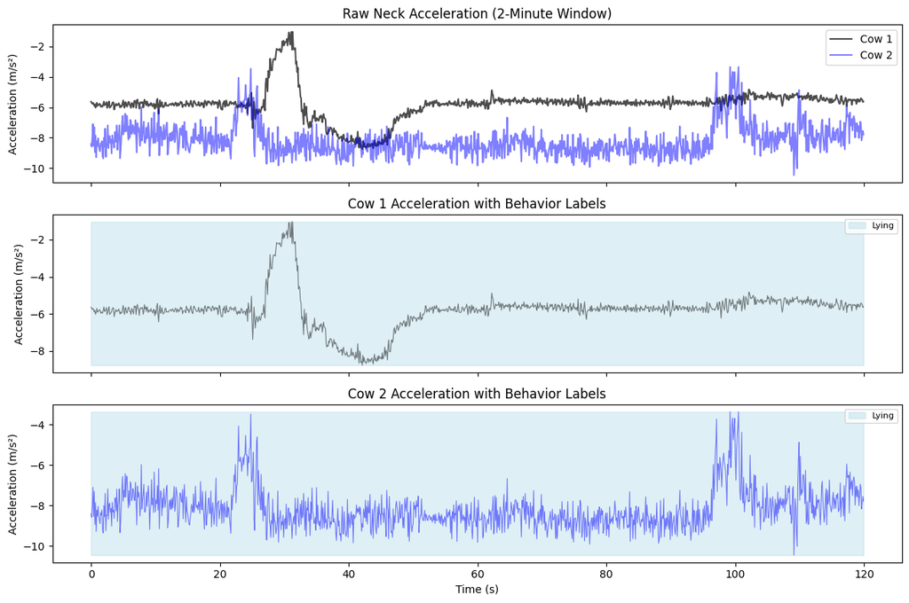

```python
# 2-minute window of raw acceleration + behavior
viz_df = df_merged.iloc[OBSERVATION_START:OBSERVATION_START + OBSERVATION_LENGTH].copy()

window_start_datetime = datetime.fromtimestamp(df_merged['timestamp'].iloc[OBSERVATION_START])
window_end_datetime = datetime.fromtimestamp(df_merged['timestamp'].iloc[OBSERVATION_START + OBSERVATION_LENGTH - 1])

print(f"Selected time window: {window_start_datetime.strftime('%Y-%m-%d %H:%M:%S')} to {window_end_datetime.strftime('%H:%M:%S')} ({len(viz_df)} samples)")

time_sec = np.arange(len(viz_df)) / SAMPLING_RATE

fig, axes = plt.subplots(3, 1, figsize=(12, 8), sharex=True)

# Panel 1: Raw acceleration
axes[0].plot(time_sec, viz_df['accel_x_mps2_c1'], label='Cow 1', color='black', alpha=0.7)
axes[0].plot(time_sec, viz_df['accel_x_mps2_c2'], label='Cow 2', color='blue', alpha=0.5)
axes[0].set_ylabel('Acceleration (m/s²)')
axes[0].set_title('Raw Neck Acceleration (2-Minute Window)')
axes[0].legend(loc='upper right')

# Panel 2: Cow 1 acceleration + behavior labels
axes[1].plot(time_sec, viz_df['accel_x_mps2_c1'], color='black', alpha=0.5, lw=0.8)
for behavior in viz_df['behavior_c1'].dropna().unique():
    mask = viz_df['behavior_c1'] == behavior
    axes[1].fill_between(time_sec, viz_df['accel_x_mps2_c1'].min(), viz_df['accel_x_mps2_c1'].max(),
                         where=mask.values, alpha=0.4,
                         color=BEHAVIOR_COLORS.get(behavior, 'lightblue'), label=behavior)
axes[1].set_ylabel('Acceleration (m/s²)')
axes[1].set_title('Cow 1 Acceleration with Behavior Labels')
axes[1].legend(loc='upper right', fontsize=8)

# Panel 3: Cow 2 acceleration + behavior labels
axes[2].plot(time_sec, viz_df['accel_x_mps2_c2'], color='blue', alpha=0.5, lw=0.8)
for behavior in viz_df['behavior_c2'].dropna().unique():
    mask = viz_df['behavior_c2'] == behavior
    axes[2].fill_between(time_sec, viz_df['accel_x_mps2_c2'].min(), viz_df['accel_x_mps2_c2'].max(),
                         where=mask.values, alpha=0.4,
                         color=BEHAVIOR_COLORS.get(behavior, 'lightblue'), label=behavior)
axes[2].set_xlabel('Time (s)')
axes[2].set_ylabel('Acceleration (m/s²)')
axes[2].set_title('Cow 2 Acceleration with Behavior Labels')
axes[2].legend(loc='upper right', fontsize=8)

plt.tight_layout(); plt.show()
```

## Part 2 Transforming a Signal Into a Phase Angle

Raw acceleration is hard to compare directly between two animals. To measure coordination, we need something more abstract. We need an instantaneous phase angle theta(t).

The intuition proceeds as follows. Any roughly rhythmic signal can be imagined as a point traveling around a circle. At each moment, that point has an angular position on the circle. That position is the phase. When two cows move in sync, their phase angles track closely together. When they are out of step, the angles diverge.

We reach this representation in two steps. First, we center the signal. We subtract the midpoint so the signal oscillates symmetrically around zero, removing the DC offset without altering the oscillatory structure. Second, we apply the Hilbert Transform. This operation lifts the real-valued signal into a complex-valued analytic signal z(t), whose argument gives us theta(t) directly. The relationship is theta(t) equals arctan of the imaginary part of z(t) divided by the real part of z(t).

The plots below show the centered signals and the resulting instantaneous phase angles for both cows. Note that for the Kuramoto animation and the sliding window analysis in Part 3, we additionally apply a bandpass filter between 0.5 and 2.5 Hz before the Hilbert transform. This isolates the movement frequencies of interest and produces cleaner phase estimates from the noisier raw signal.

[figure not shown]

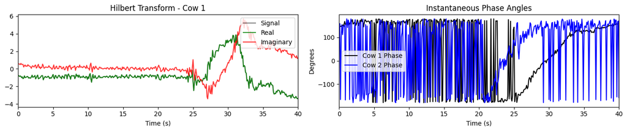

```python
# Preprocessing and Phase Extraction
sig1 = center_signal(viz_df['accel_x_mps2_c1'].values)
sig2 = center_signal(viz_df['accel_x_mps2_c2'].values)

# Visualize preprocessing result
plt.figure(figsize=(12, 3))
plt.plot(time_sec, sig1, label='Cow 1 (filtered)', color='black')
plt.plot(time_sec, sig2, label='Cow 2 (filtered)', color='blue', linestyle='--')
plt.title(f'Pre-Processed X-Axis Acceleration (Centered & Bandpass {BANDPASS_LOWFREQ}–{BANDPASS_HIGHFREQ} Hz)')
plt.xlabel('Time (s)'); plt.ylabel('Acceleration (m/s²)')
plt.legend(); plt.show()

# Hilbert Transform & Phase Extraction
phase1_deg, ht1 = extract_phase_angles(sig1)
phase2_deg, ht2 = extract_phase_angles(sig2)

# Convert to radians for animation
phase1_rad = np.deg2rad(phase1_deg)
phase2_rad = np.deg2rad(phase2_deg)

# Visualize analytic signal components (zoomed to first 30s)
fig, axes = plt.subplots(1, 2, figsize=(14, 3))
axes[0].plot(time_sec, sig1, color='black', alpha=0.5, label='Signal')
axes[0].plot(time_sec, np.real(ht1), color='green', alpha=0.8, label='Real')
axes[0].plot(time_sec, np.imag(ht1), color='red', alpha=0.8, label='Imaginary')
axes[0].set_xlim(0, 40); axes[0].set_title('Hilbert Transform - Cow 1')
axes[0].set_xlabel('Time (s)'); axes[0].legend(loc='upper right')

axes[1].plot(time_sec, phase1_deg, color='black', label='Cow 1 Phase')
axes[1].plot(time_sec, phase2_deg, color='blue', label='Cow 2 Phase')
axes[1].set_title('Instantaneous Phase Angles')
axes[1].set_xlim(0, 40)
axes[1].set_xlabel('Time (s)'); axes[1].set_ylabel('Degrees')
axes[1].legend()
plt.tight_layout(); plt.show()
```

```python
# Kuramoto Phase Animation: Both Cows on the Same Circle

mp4 = create_kuramoto_animation(
    sig1, sig2, time_sec,
    anim_start=0*SAMPLING_RATE, anim_duration=40,
    mp4_filename='./kuramoto_phase_animation.mp4'
)
display(Video(mp4, embed=True))
```

```
Rendering 2400 frames (40s at 60fps)...
  Window: 0.0–39.9 seconds
  Saved to ./kuramoto_phase_animation.mp4
```

[video not shown]

### Visualizing Phase Using the Kuramoto Framework

The animation above puts both cows on the same unit circle. Each dot's angular position is its Hilbert-transform phase at that instant. Black represents Cow 1, blue represents Cow 2. The red arc connecting them is the instantaneous relative phase. The shorter the arc, the more synchronized the two animals are at that moment.

When the dots orbit at the same speed and stay close together, the cows are in-phase. When one laps the other, or they sit on opposite sides of the circle, there is no coordination. The arc length is exactly the quantity the CRP formalizes. Watching it fluctuate in real time makes the abstraction more concrete.

### From Phase to Coordination Through Continuous Relative Phase

The Continuous Relative Phase at each sample is simply the angular distance between the two oscillators. The formula is CRP(t) equals the absolute value of theta_1(t) minus theta_2(t).

CRP approximately equal to 0 degrees indicates cows moving in-phase with concurrent synchrony. CRP approximately equal to 180 degrees indicates cows moving in anti-phase. CRP scattered across 0 to 180 degrees indicates no dominant coordination pattern.

We apply the Ippersiel et al. (2021) correction to fold values outside the natural 0 to 180 degree range back in.

The phase plane plot alongside the CRP shows each cow's acceleration signal against its own rate of change, also called a phase portrait. A tight, repeating loop suggests a stable oscillation. A diffuse cloud suggests irregular or multi-frequency movement.

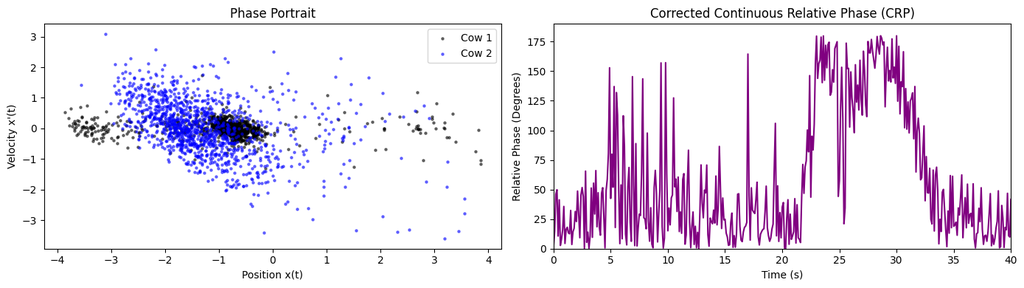

```python
fig, axs = plt.subplots(1, 2, figsize=(14, 4))

# Phase Portrait
vel1 = np.diff(sig1)
vel2 = np.diff(sig2)
axs[0].scatter(sig1[:-1], vel1, s=5, alpha=0.5, label='Cow 1', color='black')
axs[0].scatter(sig2[:-1], vel2, s=5, alpha=0.5, label='Cow 2', color='blue')
axs[0].set_title('Phase Portrait')
axs[0].set_xlabel('Position x(t)'); axs[0].set_ylabel("Velocity x'(t)")
axs[0].legend()

# Continuous Relative Phase (with Ippersiel correction)
crp_corrected = compute_crp(phase1_deg, phase2_deg)

axs[1].plot(time_sec, crp_corrected, color='purple', lw=1.5)
axs[1].set_title('Corrected Continuous Relative Phase (CRP)')
axs[1].set_xlabel('Time (s)'); axs[1].set_ylabel('Relative Phase (Degrees)')
axs[1].set_ylim(0, 190)
axs[1].set_xlim(0, 40)

plt.tight_layout(); plt.show()
```

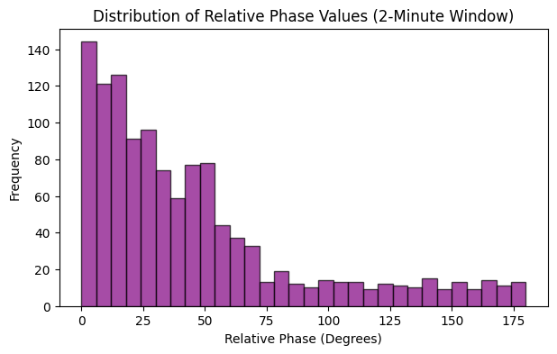

```
Circular Mean of CRP: 26.06°

in-phase (concurrent) synchrony in this window.
```

```python
# CRP Distribution & Circular Mean
fig, ax = plt.subplots(figsize=(7, 4))
ax.hist(crp_corrected, bins=30, color='purple', edgecolor='black', alpha=0.7)
ax.set_title('Distribution of Relative Phase Values (2-Minute Window)')
ax.set_xlabel('Relative Phase (Degrees)'); ax.set_ylabel('Frequency')
plt.show()

crp_rad = np.deg2rad(crp_corrected)
circ_mean_deg = np.rad2deg(circmean(crp_rad, high=np.pi, low=0))
print(f"Circular Mean of CRP: {circ_mean_deg:.2f}°")
print()
if circ_mean_deg < 45:
    print("in-phase (concurrent) synchrony in this window.")
elif circ_mean_deg > 135:
    print("anti-phase synchrony in this window.")
else:
    print("No dominant coordination pattern. Movements appear largely independent.")
```

## Part 3 Testing Whether Coordination Depends on Behavioral Context

The CRP we just computed is a snapshot. It captures one 2-minute window. However, coordination is not a fixed property as it depends on context. It might emerge when both cows are at the trough and dissolve when one is lying down and the other is walking.

To check, we run a sliding window analysis across the full day. Every 2.5 minutes, with 50% overlap, we extract a 5-minute window. We then bandpass filter both signals, compute the full CRP time series, and summarize it with a circular mean. This is a phase-aware average that correctly handles the wraparound at 0 and 360 degrees. Each window is tagged with the dominant behavior label for each cow.

```python
# Sliding Window CRP Analysis across the full day
results = []
total_windows = len(range(0, len(df_merged) - WINDOW_SIZE_SAMPLES, WINDOW_STEP_SIZE))

for i, start in enumerate(range(0, len(df_merged) - WINDOW_SIZE_SAMPLES, WINDOW_STEP_SIZE)):

    # no need to print every window, just every 50 to track progress
    if (i + 1) % 50 == 0:
        print(f"  Processing window {i + 1}/{total_windows}...")

    end = start + WINDOW_SIZE_SAMPLES
    window_df = df_merged.iloc[start:end]

    # Preprocess
    s1 = bandpass_filter(center_signal(window_df['accel_x_mps2_c1'].values))
    s2 = bandpass_filter(center_signal(window_df['accel_x_mps2_c2'].values))

    # Extract phases and compute CRP
    p1, _ = extract_phase_angles(s1)
    p2, _ = extract_phase_angles(s2)
    crp = compute_crp(p1, p2)

    # Circular mean
    mean_crp = np.rad2deg(circmean(np.deg2rad(crp), high=np.pi, low=0))

    # Dominant behavior in this window (both cows)
    dom_behavior_c1 = window_df['behavior_c1'].mode()[0] if window_df['behavior_c1'].notna().any() else 'Unknown'
    dom_behavior_c2 = window_df['behavior_c2'].mode()[0] if window_df['behavior_c2'].notna().any() else 'Unknown'

    results.append({
        'window_start': start,
        'timestamp': window_df['timestamp'].iloc[0],
        'mean_crp': mean_crp,
        'behavior_c1': dom_behavior_c1,
        'behavior_c2': dom_behavior_c2,
        'behavior_pair': f"{dom_behavior_c1} / {dom_behavior_c2}"
    })

results_df = pd.DataFrame(results)
print(f"\nComputed CRP for {len(results_df)} overlapping windows ({WINDOW_SIZE_MINUTES}-min windows with {WINDOW_OVERLAP_PERCENT}% overlap)")
print(f"Cow 1 behavior breakdown:\n{results_df['behavior_c1'].value_counts()}")
print(f"\nCow 2 behavior breakdown:\n{results_df['behavior_c2'].value_counts()}")
```

```
  Processing window 50/553...
  Processing window 100/553...
  Processing window 150/553...
  Processing window 200/553...
  Processing window 250/553...
  Processing window 300/553...
  Processing window 350/553...
  Processing window 400/553...
  Processing window 450/553...
  Processing window 500/553...
  Processing window 550/553...

Computed CRP for 553 overlapping windows (5-min windows with 50% overlap)
Cow 1 behavior breakdown:
behavior_c1
Lying                289
Standing              98
Unknown               96
Feeding head down     50
Feeding head up       11
Drinking               9
Name: count, dtype: int64

Cow 2 behavior breakdown:
behavior_c2
Lying                211
Standing             137
Unknown               98
Feeding head down     96
Licking                7
Feeding head up        4
Name: count, dtype: int64
```

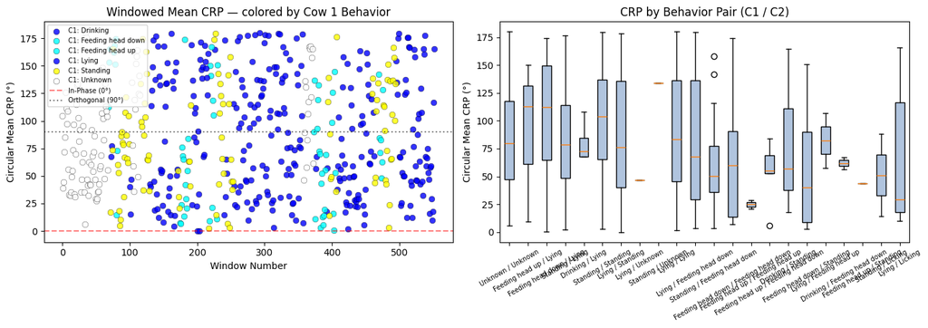

```python
# Visualization of synchrony by behavior
fig, axes = plt.subplots(1, 2, figsize=(14, 5))

# Panel 1: Time series of CRP colored by Cow 1 behavior
for behavior, group in results_df.groupby('behavior_c1'):
    axes[0].scatter(group.index, group['mean_crp'], label=f'C1: {behavior}',
                    c=BEHAVIOR_COLORS.get(behavior, 'blue'), s=40, alpha=0.8, edgecolor='black', lw=0.3)
axes[0].axhline(y=0, color='r', linestyle='--', alpha=0.5, label='In-Phase (0°)')
axes[0].axhline(y=90, color='black', linestyle=':', alpha=0.5, label='Orthogonal (90°)')
axes[0].set_title('Windowed Mean CRP — colored by Cow 1 Behavior')
axes[0].set_xlabel('Window Number'); axes[0].set_ylabel('Circular Mean CRP (°)')
axes[0].set_ylim(-10, 190); axes[0].legend(fontsize=7)

# Panel 2: Box plot comparing CRP by behavior pair
pairs_present = results_df['behavior_pair'].unique()
data_by_pair = [results_df[results_df['behavior_pair'] == p]['mean_crp'].values for p in pairs_present]
bp = axes[1].boxplot(data_by_pair, labels=pairs_present, patch_artist=True)
for patch in bp['boxes']:
    patch.set_facecolor('lightsteelblue')
axes[1].set_title('CRP by Behavior Pair (C1 / C2)')
axes[1].set_ylabel('Circular Mean CRP (°)')

axes[1].tick_params(axis='x', labelrotation=30, labelsize=7)
plt.tight_layout(); plt.show()
```

# Conclusion

This portfolio examined coordination patterns in dairy cow feeding behavior through the lens of complex systems theory. The analysis transformed raw neck acceleration data from two cows into instantaneous phase angles using the Hilbert Transform, then measured their Continuous Relative Phase across an entire day. We applied a sliding window approach to 832,486 aligned IMU samples, computing circular mean CRP values for 553 overlapping windows while tracking behavioral context from human annotations.